# Praca Domowa 2

Agata Makarewicz

6 04 2021

### Wstęp

Naszym zadaniem będzie analiza wyjaśniająca decyzję modelu uczenia maszynowego (w jaki sposób poszczególne zmienne na nią wpływają). Będą to wyjaśnienia lokalne, dla pojedynczych predykcji.

Skorzystamy ze zbioru danych `phones` zawierającego informacje o cechach różnych telefonów dostępnych na rynku. Rozważamy problem regresji (chcemy przewidzieć zmienną `price`) przy wykorzystaniu lasu losowego zaimplementowany w pakiecie `ranger`. Analizy dokonamy na poniższych obserwacjach:

|  | name | brand | back_camera_mpix | front_camera_mpix | battery_mAh | ram_gb | flash_gb | diag | height_px | width_px | price |
| --- | --- | --- | --- | --- | --- | --- | --- | --- | --- | --- | --- |
| 1 | Xiaomi Mi 10T 6+128GB | Xiaomi | 64 | 20 | 5000 | 6 | 128 | 6.67 | 2400 | 1080 | 1999 |
| 10 | Xiaomi Redmi 9C 2/32GB | Xiaomi | 13 | 5 | 5000 | 2 | 32 | 6.53 | 1600 | 720 | 480 |
| 50 | Samsung Galaxy A20s | Samsung | 13 | 8 | 4000 | 3 | 32 | 6.50 | 1560 | 720 | 799 |
| 70 | OPPO Reno3 | OPPO | 48 | 44 | 4025 | 8 | 128 | 6.40 | 2400 | 1080 | 1399 |
| 100 | Realme X50 5G 6/128GB | Realme | 48 | 16 | 4200 | 6 | 128 | 6.57 | 2400 | 1080 | 1499 |
| 334 | Huawei P smart Pro | Huawei | 48 | 16 | 4000 | 6 | 128 | 6.59 | 2310 | 1080 | 1099 |

Zbiór posiada ok. 11% obserwacji z brakującymi wartościami w niektórych kolumnach, na potrzeby tego zadania (tworzenia modelu) rekordy te zostaną pominięte. Pominiemy również zmienną `name`, która jest w oczywisty sposób skorelowana ze zmienną `brand` oraz praktycznie unikalna dla każdej obserwacji (328/368 wartości unikalnych po usunięciu braków).

### Model & explainer

```r
model <- ranger(price~., data = data[,-1], num.trees = 50)
explainer <- DALEX::explain(model = model, data = data[,-c(1,11)], y = data$price)
```

### Wyliczenie predykcji dla wybranej obserwacji

```r
predict(model, data[1,])$predictions
```

```
## [1] 2588.7
```

### Dekompozycja predykcji

#### LIME dla wybranej obserwacji

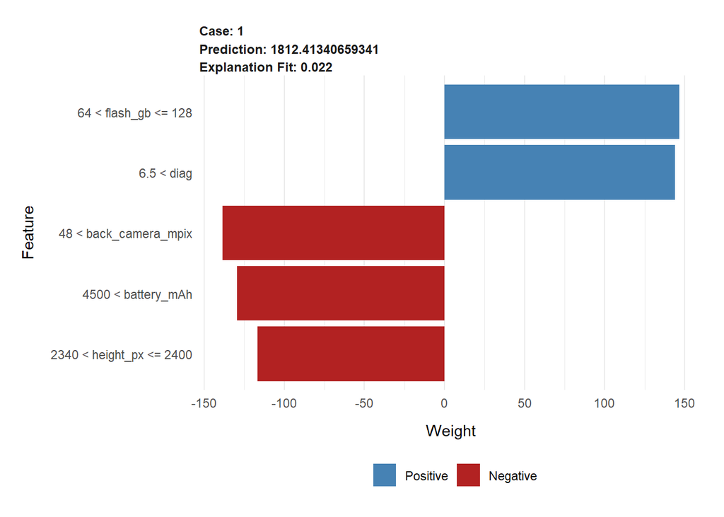

```r
data[1,11]
```

```
## [1] 1999
```

Predykcja modelu liniowego przybliżającego w obserwacji 1 nasz model jest całkiem niezła patrząc na prawdziwą cenę rozważanego telefonu. W tym przypadku pozytywnie wpłynęły na nią pojemność pamięci flash (z przedziału (64,128)GB ) oraz przekątna powyżej 6.5 cali, co jest dość logiczne - takie parametry zazwyczaj faktycznie powodują wzrost ceny telefonu. Negatywny wpływ ma natomiast rozdzielczość aparatu, pojemność baterii oraz wysokość, co w przypadku dwóch pierwszych zmiennych jest dość dziwne, ponieważ te parametry są dosyć wysokie (dobre) i powinny raczej powodować wzrost ceny.

$~$

#### LIME dla kilku obserwacji

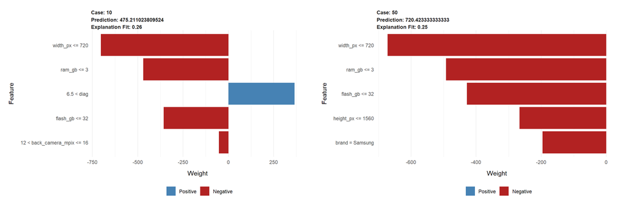

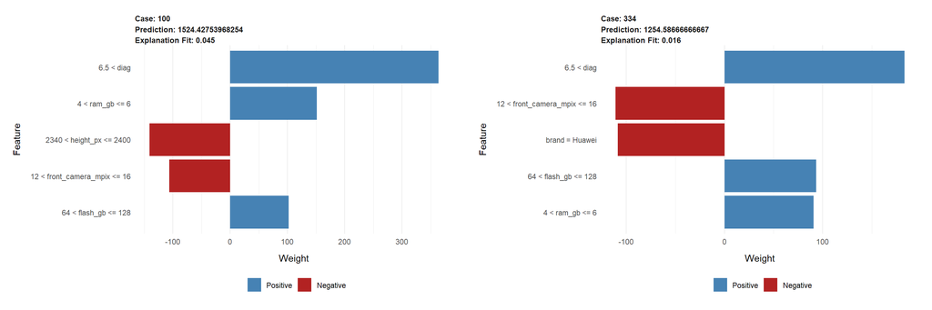

Porównując wyjaśnienia LIME dla wybranych 4 obserwacji możemy zaobserwować pewną stabilność: przekątna powyżej 6.5 cala, o ile występuje, ma dosyć spory pozytywny wpływ na cenę telefonu, podobnie pamięć RAM z zakresu 4-6 GB oraz pamięć flash z przedziału 64-128 GB. Są to bardzo dobre parametry więc nic dziwnego, że podwyższają one cenę telefonu - w rzeczywistości również ma to miejsce.

Jeśli spojrzymy na negatywne wpływy to również możemy zaobserwować powtarzalność - pamięć flash poniżej 32 GB jak na obecne standardy nie jest zbyt duża, więc to normalne, że powoduje obniżenie ceny. Podobnie szerokość poniżej 720 px czy pamięć RAM poniżej 3 GB lub też rozdzielczość tylniego aparatu z przedziału 12-16 mpix.

$~$

#### Breakdown vs LIME dla wybranej obserwacji

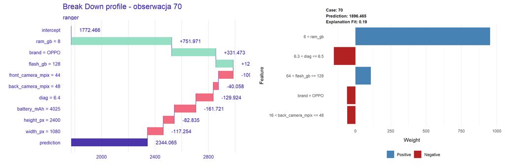

Porównując dekompozycję BreakDown oraz LIME możemy zauważyć w większości te same wpływy danych zmiennych (nie co do wartości wpływu ale w kontekście pozytywny/negatywny). Największy wpływ na plus ma pamięć RAM 8 GB, drugi w kolejności (w przypadku LIME ograniczonego do 5 zmiennych a trzeci w przypadku BreakDown) ma zmienna określająca pojemność pamięci flash. Oba te parametry są bardzo dobre więc nie dziwi podwyższenie przez nie ceny. Zmienne określające przekątną oraz rozdzielczość aparatu w obu dekompozycjach mają wpływ negatywny. Wyjątek tutaj stanowi zmienna brand, która w dekompozycji BreakDown ma wyraźny pozytywny wpływ na predykcję naszego modelu, a w przypadku modelu liniowego w dekompozycji LIME - negatywny (niezbyt duży). Takie porównanie dwóch dekompozycji zyskuje też na tym, że możemy zobaczyć w który “kraniec przedziału” określonego przez LIME wpada nasza faktyczna wartość - np w przypadku aparatu jest to górna granica, stąd zapewne znikomy negatywny wpływ.

### Wnioski

Przeprowadzone analizy dotyczyły pojedynczych predykcji, i mimo zaobserwowanej “stabilności” metody LIME, na ich podstawie ciężko jest wyciągać wnioski dotyczące ogólnego działania naszego modelu. Do zauważenia ogólnych tendencji/wpływów należałoby użyć innych narzędzi, umożliwiających globalne wyjaśnienia. Jednak fakt, że rozważaliśmy telefony różnych marek, z różnych półek cenowych, a poszczególne wartości danych zmiennych niezależnie od tych różnic dawały ten sam (pozytywny/negatywny) wpływ w przypadku losowych 3-4 obserwacji, może nam dawać pewną intuicję co do ich znaczenia w dalszych etapach analizy (zarówno lokalnej jak i globalnej).